# LAB 1: Data pre-processing exercise

Lluís A. Belanche, translated to R Markdown by Marta Arias

February 2020

This exercise involves the use of the ‘Auto’ data set, which can be found in the file `Auto.data`. The file contains a number of variables for different cars.

In the following script you will find some steps that we have done for you, and at the end we list a series of tasks you should accomplish as practice for the pre-processing stage.

### Load data:

```r
graphics.off()      # reset/close all graphical devices

# read the file 'Auto.data' (data on cars)
Auto <- read.table("Auto.data", header=TRUE, na.strings="?")
summary(Auto)
```

```
##       mpg          cylinders      displacement     horsepower
##  Min.   : 9.00   Min.   :3.000   Min.   : 68.0   Min.   : 46.0
##  1st Qu.:17.50   1st Qu.:4.000   1st Qu.:104.0   1st Qu.: 75.0
##  Median :23.00   Median :4.000   Median :146.0   Median : 93.5
##  Mean   :23.52   Mean   :5.458   Mean   :193.5   Mean   :104.5
##  3rd Qu.:29.00   3rd Qu.:8.000   3rd Qu.:262.0   3rd Qu.:126.0
##  Max.   :46.60   Max.   :8.000   Max.   :455.0   Max.   :230.0
##                                                  NA's   :5
##      weight      acceleration        year           origin
##  Min.   :1613   Min.   : 8.00   Min.   :70.00   Min.   :1.000
##  1st Qu.:2223   1st Qu.:13.80   1st Qu.:73.00   1st Qu.:1.000
##  Median :2800   Median :15.50   Median :76.00   Median :1.000
##  Mean   :2970   Mean   :15.56   Mean   :75.99   Mean   :1.574
##  3rd Qu.:3609   3rd Qu.:17.10   3rd Qu.:79.00   3rd Qu.:2.000
##  Max.   :5140   Max.   :24.80   Max.   :82.00   Max.   :3.000
##
##              name
##  ford pinto    :  6
##  amc matador   :  5
##  ford maverick :  5
##  toyota corolla:  5
##  amc gremlin   :  4
##  amc hornet    :  4
##  (Other)       :368
```

### Fix some stuff first:

```r
# put proper country of origin
Auto[,"origin"] <- factor(c("USA","EU","Japan")[Auto[,"origin"]])

# convert "miles per gallon" to "liters per km"
Auto[,"mpg"] <- 235.4/Auto[,"mpg"]
colnames(Auto)[which(colnames(Auto)=="mpg")] <- "l.100km"

summary(Auto)
```

```
##     l.100km         cylinders      displacement     horsepower
##  Min.   : 5.052   Min.   :3.000   Min.   : 68.0   Min.   : 46.0
##  1st Qu.: 8.117   1st Qu.:4.000   1st Qu.:104.0   1st Qu.: 75.0
##  Median :10.235   Median :4.000   Median :146.0   Median : 93.5
##  Mean   :11.224   Mean   :5.458   Mean   :193.5   Mean   :104.5
##  3rd Qu.:13.451   3rd Qu.:8.000   3rd Qu.:262.0   3rd Qu.:126.0
##  Max.   :26.156   Max.   :8.000   Max.   :455.0   Max.   :230.0
##                                                   NA's   :5
##      weight      acceleration        year         origin
##  Min.   :1613   Min.   : 8.00   Min.   :70.00   EU   : 70
##  1st Qu.:2223   1st Qu.:13.80   1st Qu.:73.00   Japan: 79
##  Median :2800   Median :15.50   Median :76.00   USA  :248
##  Mean   :2970   Mean   :15.56   Mean   :75.99
##  3rd Qu.:3609   3rd Qu.:17.10   3rd Qu.:79.00
##  Max.   :5140   Max.   :24.80   Max.   :82.00
##
##              name
##  ford pinto    :  6
##  amc matador   :  5
##  ford maverick :  5
##  toyota corolla:  5
##  amc gremlin   :  4
##  amc hornet    :  4
##  (Other)       :368
```

### Car names:

The car name is not useful for modelling, but it may be handy to keep it as the row name

**WARNING!** surprisingly, car names are not unique, so we first prefix them by their row number

```r
Auto$name <- paste (1:nrow(Auto), Auto$name)
rownames(Auto) <- Auto$name
Auto <- subset (Auto, select=-name)
head(Auto)
```

|  | l.100km | cylinders | displacement | horsepower | weight | acceleration | year | origin |
| --- | --- | --- | --- | --- | --- | --- | --- | --- |
| 1 chevrolet chevelle malibu | 13.07778 | 8 | 307 | 130 | 3504 | 12.0 | 70 | USA |
| 2 buick skylark 320 | 15.69333 | 8 | 350 | 165 | 3693 | 11.5 | 70 | USA |
| 3 plymouth satellite | 13.07778 | 8 | 318 | 150 | 3436 | 11.0 | 70 | USA |
| 4 amc rebel sst | 14.71250 | 8 | 304 | 150 | 3433 | 12.0 | 70 | USA |
| 5 ford torino | 13.84706 | 8 | 302 | 140 | 3449 | 10.5 | 70 | USA |
| 6 ford galaxie 500 | 15.69333 | 8 | 429 | 198 | 4341 | 10.0 | 70 | USA |

### Now we go for the cylinders

```r
table(Auto$cylinders)
```

```
##
##   3   4   5   6   8
##   4 203   3  84 103
```

That’s strange, some cars have an odd number of cylinders (are these errors?)

```r
subset(Auto,cylinders==3)
```

|  | l.100km | cylinders | displacement | horsepower | weight | acceleration | year | origin |
| --- | --- | --- | --- | --- | --- | --- | --- | --- |
| 72 mazda rx2 coupe | 12.389474 | 3 | 70 | 97 | 2330 | 13.5 | 72 | Japan |
| 112 maxda rx3 | 13.077778 | 3 | 70 | 90 | 2124 | 13.5 | 73 | Japan |
| 244 mazda rx-4 | 10.948837 | 3 | 80 | 110 | 2720 | 13.5 | 77 | Japan |
| 335 mazda rx-7 gs | 9.932489 | 3 | 70 | 100 | 2420 | 12.5 | 80 | Japan |

These Mazdas wear a Wankel engine, so this is correct

```r
subset(Auto,cylinders==5)
```

|  | l.100km | cylinders | displacement | horsepower | weight | acceleration | year | origin |
| --- | --- | --- | --- | --- | --- | --- | --- | --- |
| 275 audi 5000 | 11.596059 | 5 | 131 | 103 | 2830 | 15.9 | 78 | EU |
| 298 mercedes benz 300d | 9.267717 | 5 | 183 | 77 | 3530 | 20.1 | 79 | EU |
| 328 audi 5000s (diesel) | 6.467033 | 5 | 121 | 67 | 2950 | 19.9 | 80 | EU |

Yes, these Audis displayed five-cylinder engines, so the data is correct

### Horsepower:

From `summary(Auto)` above we see that horsepower has 5 NA’s that we’ll need to take care of later …

### So, this is your departing data set:

```r
summary(Auto)
```

```
##     l.100km         cylinders      displacement     horsepower
##  Min.   : 5.052   Min.   :3.000   Min.   : 68.0   Min.   : 46.0
##  1st Qu.: 8.117   1st Qu.:4.000   1st Qu.:104.0   1st Qu.: 75.0
##  Median :10.235   Median :4.000   Median :146.0   Median : 93.5
##  Mean   :11.224   Mean   :5.458   Mean   :193.5   Mean   :104.5
##  3rd Qu.:13.451   3rd Qu.:8.000   3rd Qu.:262.0   3rd Qu.:126.0
##  Max.   :26.156   Max.   :8.000   Max.   :455.0   Max.   :230.0
##                                                   NA's   :5
##      weight      acceleration        year         origin
##  Min.   :1613   Min.   : 8.00   Min.   :70.00   EU   : 70
##  1st Qu.:2223   1st Qu.:13.80   1st Qu.:73.00   Japan: 79
##  Median :2800   Median :15.50   Median :76.00   USA  :248
##  Mean   :2970   Mean   :15.56   Mean   :75.99
##  3rd Qu.:3609   3rd Qu.:17.10   3rd Qu.:79.00
##  Max.   :5140   Max.   :24.80   Max.   :82.00
##
```

### A plot from Lecture 1 …

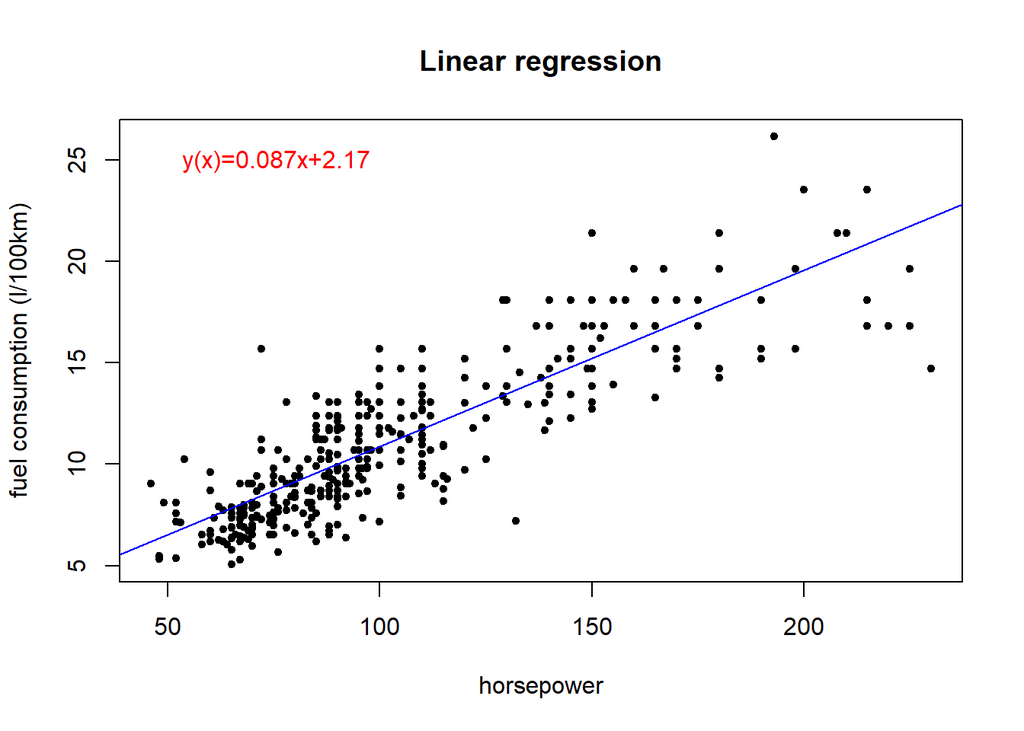

```r
with (Auto, Auto.lm <<- lm(l.100km ~ horsepower, Auto))

plot(Auto[,"horsepower"],Auto[,"l.100km"],
     pch=20,
     xlab="horsepower",ylab="fuel consumption (l/100km)",
     main="Linear regression")

# add regression line
a <- Auto.lm$coefficients["(Intercept)"]
b <- Auto.lm$coefficients["horsepower"]
abline(a=a,b=b,col="blue")
text(50,25,sprintf("y(x)=%.3fx+%.2f",b,a),col="red",pos=4)
```

### In order to create quick LaTeX code, try this:

```r
library(xtable)
xtable(Auto[1:4,])
```

|  | l.100km | cylinders | displacement | horsepower | weight | acceleration | year | origin |
| --- | --- | --- | --- | --- | --- | --- | --- | --- |
| 1 chevrolet chevelle malibu | 13.07778 | 8 | 307 | 130 | 3504 | 12.0 | 70 | USA |
| 2 buick skylark 320 | 15.69333 | 8 | 350 | 165 | 3693 | 11.5 | 70 | USA |
| 3 plymouth satellite | 13.07778 | 8 | 318 | 150 | 3436 | 11.0 | 70 | USA |
| 4 amc rebel sst | 14.71250 | 8 | 304 | 150 | 3433 | 12.0 | 70 | USA |

```r
xtable(Auto.lm)
```

|  | Estimate | Std. Error | t value | Pr(>\|t\|) |
| --- | --- | --- | --- | --- |
| (Intercept) | 2.16994989 | 0.297670868 | 7.289762 | 1.741384e-12 |
| horsepower | 0.08698672 | 0.002674065 | 32.529776 | 3.721209e-113 |

Wasn’t that nice?

```r
# this is a list of R objects that can be embedded into a LaTeX table code:
methods(xtable)
```

```
##  [1] xtable.anova*           xtable.aov*
##  [3] xtable.aovlist*         xtable.coxph*
##  [5] xtable.data.frame*      xtable.glm*
##  [7] xtable.lm*              xtable.matrix*
##  [9] xtable.prcomp*          xtable.summary.aov*
## [11] xtable.summary.aovlist* xtable.summary.glm*
## [13] xtable.summary.lm*      xtable.summary.prcomp*
## [15] xtable.table*           xtable.ts*
## [17] xtable.zoo*
## see '?methods' for accessing help and source code
```

### Exercise for the lab session:

1. Print the dimensions of the data set
2. Identify possible target variables according to classification or regression problems
3. Inspect the first 4 examples and the predictive variables 6 and 7 for the tenth example
4. Perform a basic inspection of the dataset. Have a look at the minimum and maximum values for each variable; find possible errors and abnormal values (outliers); find possible missing values; decide which variables are really continuous and which are really categorical and convert them
5. Make a decision on a sensible treatment for the missing values and apply it;

**WARNING!** `origin` is categorical and cannot be used for knn imputation, unless you make it binary temporarily

6. Derive one new continuous variable: weight/horsepower; derive one new categorical variable: sports_car, satisfying horsepower > 1.2*mean(horsepower) AND acceleration < median(acceleration); do you think this new variable is helpful in predicting ‘origin’ ?
7. Create a new dataframe that gathers everything and inspect it again
8. Perform a graphical summary of some of the variables (both categorical and continuous)
9. Perform a graphical comparison between some pairs of variables (both categorical and continuous)
10. Do any of the continuous variables “look” Gaussian? can you transform some variable so that it looks more so?
11. Create a new dataframe that gathers everything and inspect it again; consider ‘origin’ as the target variable; perform a basic statistical analysis as indicated in Section 9 of the example script
12. Shuffle the final dataset and save it into a file for future use

### Your code starts here …

1. Print the dimensions of the data set.

```r
dim(Auto)
```

```
## [1] 397   8
```

2. Identify possible target variables according to classification or regression problems.

```r
names(Auto)
```

```
## [1] "l.100km"      "cylinders"    "displacement" "horsepower"
## [5] "weight"       "acceleration" "year"         "origin"
```